# Homework 1

Michael Pearce

2023-03-17 13:07:22

## Explanatory Analyses

In this *swiss* dataset, we have 47 observations of 6 variables. The variable names are: Fertility, Agriculture, Examination, Education, Catholic, Infant.Mortality. In the interest of time, space, and mental exhaustion, let’s just pick one to explore!

Let’s see, maybe R can randomly pick something for us…

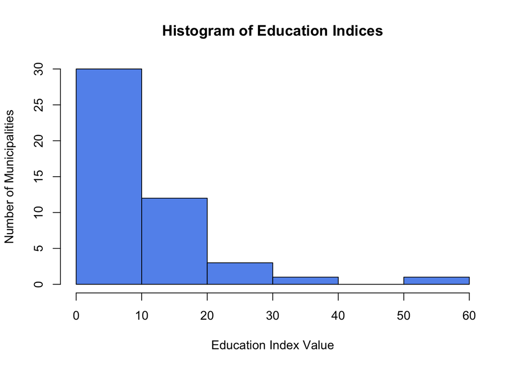

Hmm. A couple of those municipalities are way up there in this right-skewed distribution, specifically. As it stands currently, this variables has a mean of 10.98 and a standard deviation of 9.62. But since it’s so skewed, the median (8) is the better indicator of its center. It would be worth doing a log transformation to get a more normally distributed variable as we see below. We would definitely want to work with this transformed variable in any modeling.

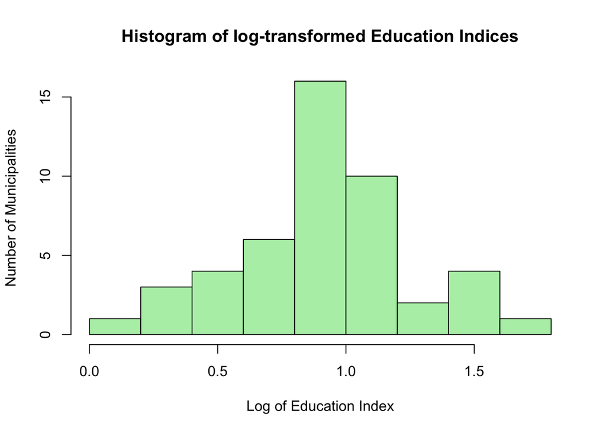

And finally, a pairwise scatterplot to give us an idea of correlative relationships to explore in the future. It’ll have to be tabled (heh) for now.

### Pairwise comparisons of *swiss* variables

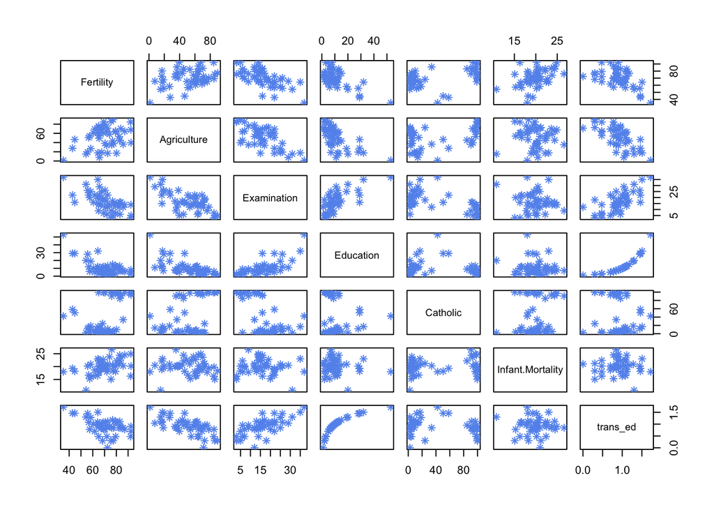